# Capstone NLP Presentation

December 13, 2018

## Predict Next Word App Overview

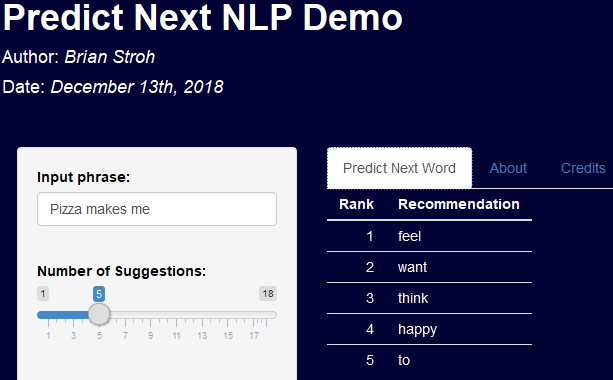

A user types a word or expression into the 'Input Phrase' text box.  
Then the user can adjust the input slider to change the number of word recommendations displayed.

## The Data Structures

10-grams on down to 1-grams were created and aggregated using the quanteda package.

Other than the 1-gram, all n-gram dataframes were sized down to frequencies >= 3.

This helped to reduce model size significantly.

The 1 gram data frame was given an index column.

To further reduce model size, the n-gram dataframes had all of their character vectors replaced by their corresponding 1-gram indices.

## The Algorithm: Part 1

The input phrase is first stripped of any punctuation, set to all lower-case, and has all contractions converted to full words.

The phrase is then split apart into a vector of individual words.

A custom function creates a vector that contains just the corresponding indices of these words from the 1-gram dataframe.

The Model: This app takes a basic layered n-gram approach to predict the next word(s).

N-gram dataframes are filtered to match preceding inidices to the exact indices from the input phrase.

The last index column from each of these filtered dataframes is assigned a weight equal to frequency of that index within the filtered dataframe divided by the sum of all filtered frequencies.

## The Algorithm: Part 2

These indices and their weights are calculated for each n-gram, discounted depending on n of the n gram and combined into a penultimate dataframe.

The 10-gram weights are not discounted, but the 9-gram weights are mulitplied by .9, the 8-gram weights are mulitplied by .8, and so on.

This dataframe is then sorted in order of decreasing weight, and then duplicate indices are removed.

A custom function then converts the vector of indices back to a vector of words from the 1-gram dataframe.

Lastly, the first few most frequent words from the 1-gram dataframe are added to the end of the ultimate vector just to fill in any potential empty results that would result from infrequent input phrases.